# Identifying Optimal Environments for Aquaculture

# Discussion

This analysis demonstrates how spatial data science can inform sustainable aquaculture planning. By integrating environmental thresholds with geospatial data sets, we identified where oysters are most likely to thrive along the U.S. West Coast. The results reveal clear spatial patterns of suitability, with Central and Southern California emerging as the most promising regions, while Washington and Oregon also contain meaningful but smaller areas of potential habitat.

Future research could extend this framework to other species with distinct environmental requirements or to climate change scenarios that alter SST and ocean depth dynamics. The methods demonstrated raster reclassification, map algebra, and zonal statistics—are versatile tools that can be applied to other contexts, such as identifying suitable elevations for grapevines or climate niches for tree species. By broadening the scope, environmental data science can continue to guide sustainable aquaculture development and ecosystem management.

```r
# Function to map EEZ suitability for a species
map_species_suitability <- function(sst_min, sst_max, depth_min, depth_max, species_name) {

# Read in data
  regions_clean <- st_read("data/wc_regions_clean.shp", quiet = TRUE)
  depth <- rast("data/depth.tif")
  sst_stack <- c(
    rast("data/average_annual_sst_2008.tif"),
    rast("data/average_annual_sst_2009.tif"),
    rast("data/average_annual_sst_2010.tif"),
    rast("data/average_annual_sst_2011.tif"),
    rast("data/average_annual_sst_2012.tif")
  )

  # Process the SST and convert to celsius
  sst_mean <- mean(sst_stack)
  sst_celsius <- sst_mean - 273.15

  # Align depth to SST
  depth_proj <- project(depth, crs(sst_celsius))
  depth_crop <- crop(depth_proj, sst_celsius)
  depth_resample <- resample(depth_crop, sst_celsius, method = "near")

  # Create suitability classification matrixes
  sst_suit <- classify(sst_celsius,
                       rbind(c(-Inf, sst_min, 0),
                             c(sst_min, sst_max, 1),
                             c(sst_max, Inf, 0)))

  depth_suit <- classify(depth_resample,
                         rbind(c(-Inf, depth_min, 0),
                               c(depth_min, depth_max, 1),
                               c(depth_max, Inf, 0)))

  suitability <- sst_suit * depth_suit

  # Create EEZ zonal stats

  # Convert cleaned EEZ regions to vector
  eez_v <- vect(regions_clean)

  # Reproject the EEZ vector to match CRS of sst_celsius
  eez_v <- project(eez_v, crs(sst_celsius))

  # Add unique ID for each EEZ zone for later join
  eez_v$eez_id <- seq_len(nrow(eez_v))

  # Rasterize the EEZ polygon so each cell in raster is assigned an ID that is within
  eez_r <- rasterize(eez_v, sst_celsius, field = "eez_id")

  # Calculate the area of each raster in square kilometers
  cell_area <- cellSize(sst_celsius, unit = "km")

  # Multiply the suitability raster by cell area to get area of suitable habitat per cell
  area_suitable <- suitability * cell_area

  # Perform zonal math by getting the sum of the suitable area in each EEZ zone
  area_by_eez <- zonal(area_suitable, eez_r, fun = "sum", na.rm = TRUE)

  # Convert above results into a dataframe and rename column
  area_by_eez <- as.data.frame(area_by_eez) |>
    rename(suitable_km2 = mean)

  # Convert EEZ vector back to an sf obejct and join stats by EEZ ID
  eez_sf_out <- st_as_sf(eez_v) |>
    left_join(area_by_eez, by = "eez_id")

# Plot map
  tm_shape(eez_sf_out) +
    tm_polygons(fill = "suitable_km2",
                fill.scale = tm_scale(values = "viridis"),
                fill.legend = tm_legend(title = "Suitable area (km²)")) +
    tm_title(paste(species_name, "Suitability Across West Coast EEZs"),
             position = c("center", "top")) +
    tm_scalebar(position = c("left", "bottom")) +
    tm_compass(position = c("right", "top"))
}
```

```
[plot mode] fit legend/component: Some legend items or map compoments do not
fit well, and are therefore rescaled.
ℹ Set the tmap option `component.autoscale = FALSE` to disable rescaling.
```

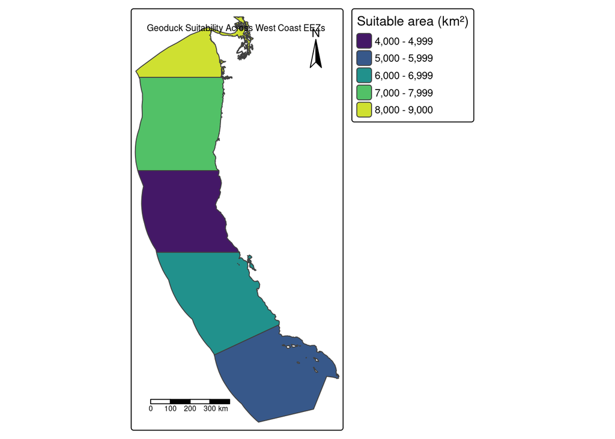

```r
# Use the function for finding suitable area for Geoducks

# map_species_suitability(sst_min, sst_max, depth_min, depth_max, species_name)
map_species_suitability(sst_min = 0, sst_max = 80, depth_min = -100, depth_max = 0, species_name = "Geoduck")
```

# References

SeaLifeBase. (2025). Species depth and temperature requirements. https://www.sealifebase.ca/search.php [Accessed Nov. 2025]

NOAA Coral Reef Watch. (2025). 5‑km Sea Surface Temperature Anomaly Product. https://coralreefwatch.noaa.gov/product/5km/index_5km_ssta.php [Accessed Nov. 2025]

GEBCO. (2025). Gridded Bathymetry Data. https://www.gebco.net/data-products/gridded-bathymetry-data#area [Accessed Nov. 2025]

Marine Regions. (2025). Exclusive Economic Zones (EEZs). https://www.marineregions.org/eez.php [Accessed Nov. 2025]